# DDS_401_TeamNI_Case_Study_2

Michael J Wolfe & Ayoade Dare

February 23, 2019

# Career Attrition Analysis for DDS Talent Management

# NaturalIntelligence Analytics

NaturalIntelligence Analytics would like to thank DDS Talent Management for the opportunity to explore job attrition data! The codebook below is intended to load, clean, and explore the data supplied to us for the purpose of discovering the top 3 factors that lead to attrition. Let’s get started!

## Let’s set up our environment and load the data!

```r
suppressMessages(library(randomForest))
suppressMessages(library(randomForestExplainer))
suppressMessages(library(pscl))
```

```r
suppressMessages(library(RCurl))
suppressMessages(library(ggplot2))
suppressMessages(library(nnet))
suppressMessages(library(kableExtra))
suppressMessages(library(broom))
jobURL <- getURL("https://raw.githubusercontent.com/mjwolfe91/DDS_401_TeamNI_Case_Study2/master/Data/CaseStudy2-data.csv")
jobDF <- read.csv(text=jobURL, header=TRUE)
kable(head(jobDF), format = "html", align = "c") %>% kable_styling(bootstrap_options = c("striped", "hover"))
```

| X.U.FEFF.Age | Attrition | BusinessTravel | DailyRate | Department | DistanceFromHome | Education | EducationField | EmployeeCount | EmployeeNumber | EnvironmentSatisfaction | Gender | HourlyRate | JobInvolvement | JobLevel | JobRole | JobSatisfaction | MaritalStatus | MonthlyIncome | MonthlyRate | NumCompaniesWorked | Over18 | OverTime | PercentSalaryHike | PerformanceRating | RelationshipSatisfaction | StandardHours | StockOptionLevel | TotalWorkingYears | TrainingTimesLastYear | … |
| --- | --- | --- | --- | --- | --- | --- | --- | --- | --- | --- | --- | --- | --- | --- | --- | --- | --- | --- | --- | --- | --- | --- | --- | --- | --- | --- | --- | --- | --- | --- |
| 41 | Yes | Travel_Rarely | 1102 | Sales | 1 | 2 | Life Sciences | 1 | 1 | 2 | Female | 94 | 3 | 2 | Sales Executive | 4 | Single | 5993 | 19479 | 8 | Y | Yes | 11 | 3 | 1 | 80 | 0 | 8 | 0 | … |
| 49 | No | Travel_Frequently | 279 | Research & Development | 8 | 1 | Life Sciences | 1 | 2 | 3 | Male | 61 | 2 | 2 | Research Scientist | 2 | Married | 5130 | 24907 | 1 | Y | No | 23 | 4 | 4 | 80 | 1 | 10 | 3 | … |
| 37 | Yes | Travel_Rarely | 1373 | Research & Development | 2 | 2 | Other | 1 | 4 | 4 | Male | 92 | 2 | 1 | Laboratory Technician | 3 | Single | 2090 | 2396 | 6 | Y | Yes | 15 | 3 | 2 | 80 | 0 | 7 | 3 | … |
| 33 | No | Travel_Frequently | 1392 | Research & Development | 3 | 4 | Life Sciences | 1 | 5 | 4 | Female | 56 | 3 | 1 | Research Scientist | 3 | Married | 2909 | 23159 | 1 | Y | Yes | 11 | 3 | 3 | 80 | 0 | 8 | 3 | … |
| 27 | No | Travel_Rarely | 591 | Research & Development | 2 | 1 | Medical | 1 | 7 | 1 | Male | 40 | 3 | 1 | Laboratory Technician | 2 | Married | 3468 | 16632 | 9 | Y | No | 12 | 3 | 4 | 80 | 1 | 6 | 3 | … |
| 32 | No | Travel_Frequently | 1005 | Research & Development | 2 | 2 | Life Sciences | 1 | 8 | 4 | Male | 79 | 3 | 1 | Laboratory Technician | 4 | Single | 3068 | 11864 | 0 | Y | No | 13 | 3 | 3 | 80 | 0 | 8 | 2 | … |

```r
#kable(head(jobDF), align = "c") %>% kable_styling(bootstrap_options = c("striped", "hover"))
```

## Hmmm, looks like there’s a little cleanup to do…let’s stratify some of the variables

```r
str(jobDF)
```

```
## 'data.frame':    1470 obs. of  35 variables:
##  $ X.U.FEFF.Age            : int  41 49 37 33 27 32 59 30 38 36 ...
##  $ Attrition               : Factor w/ 2 levels "No","Yes": 2 1 2 1 1 1 1 1 1 1 ...
##  $ BusinessTravel          : Factor w/ 3 levels "Non-Travel","Travel_Frequently",..: 3 2 3 2 3 2 3 3 2 3 ...
##  $ DailyRate               : int  1102 279 1373 1392 591 1005 1324 1358 216 1299 ...
##  $ Department              : Factor w/ 3 levels "Human Resources",..: 3 2 2 2 2 2 2 2 2 2 ...
##  $ DistanceFromHome        : int  1 8 2 3 2 2 3 24 23 27 ...
##  $ Education               : int  2 1 2 4 1 2 3 1 3 3 ...
##  $ EducationField          : Factor w/ 6 levels "Human Resources",..: 2 2 5 2 4 2 4 2 2 4 ...
##  $ EmployeeCount           : int  1 1 1 1 1 1 1 1 1 1 ...
##  $ EmployeeNumber          : int  1 2 4 5 7 8 10 11 12 13 ...
##  $ EnvironmentSatisfaction : int  2 3 4 4 1 4 3 4 4 3 ...
##  $ Gender                  : Factor w/ 2 levels "Female","Male": 1 2 2 1 2 2 1 2 2 2 ...
##  $ HourlyRate              : int  94 61 92 56 40 79 81 67 44 94 ...
##  $ JobInvolvement          : int  3 2 2 3 3 3 4 3 2 3 ...
```

[output cut: 21 more lines]

```r
jobDF$AgeGroup <- cut(jobDF$X.U.FEFF.Age, c(-Inf, 20, 29, 39, 49, 59, Inf))
levels(jobDF$AgeGroup) <- c("<20", "20-29", "30-39", "40-49", "50-59", "60+")
jobDF$GenderInd <- 0
jobDF[jobDF$Gender == "Male", ]$GenderInd <- 1
drops <- c("X.U.FEFF.Age","Gender")
jobDF <- jobDF[ , !(names(jobDF) %in% drops)]
```

## Let’s do some exploratory data analysis

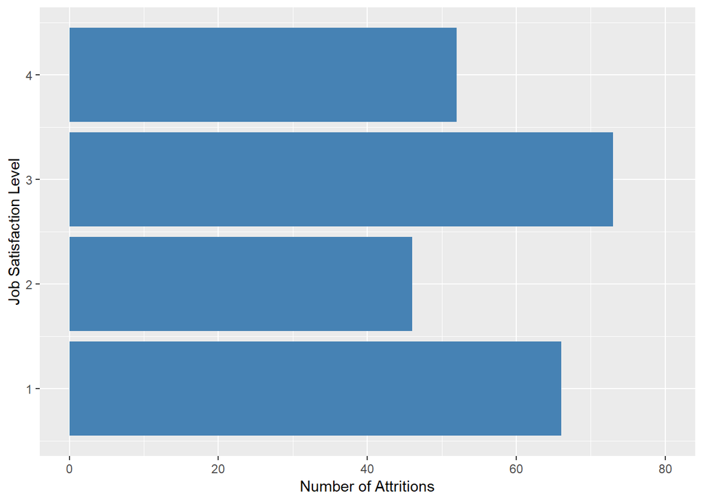

```r
jobDF.eda <- jobDF
jobDF.eda$AttritionInd <- 0
jobDF.eda[jobDF.eda$Attrition == "Yes", ]$AttritionInd <- 1
JSsum <- aggregate(jobDF.eda$AttritionInd, by=list(Category=jobDF.eda$JobSatisfaction), FUN=sum)
ggplot(JSsum, aes(y=x, x=Category)) + geom_bar(position="dodge", stat="identity", fill=c("steelblue")) + scale_x_continuous(name="Job Satisfaction Level") + scale_y_continuous(name="Number of Attritions", limits=c(0, 80)) + coord_flip()
```

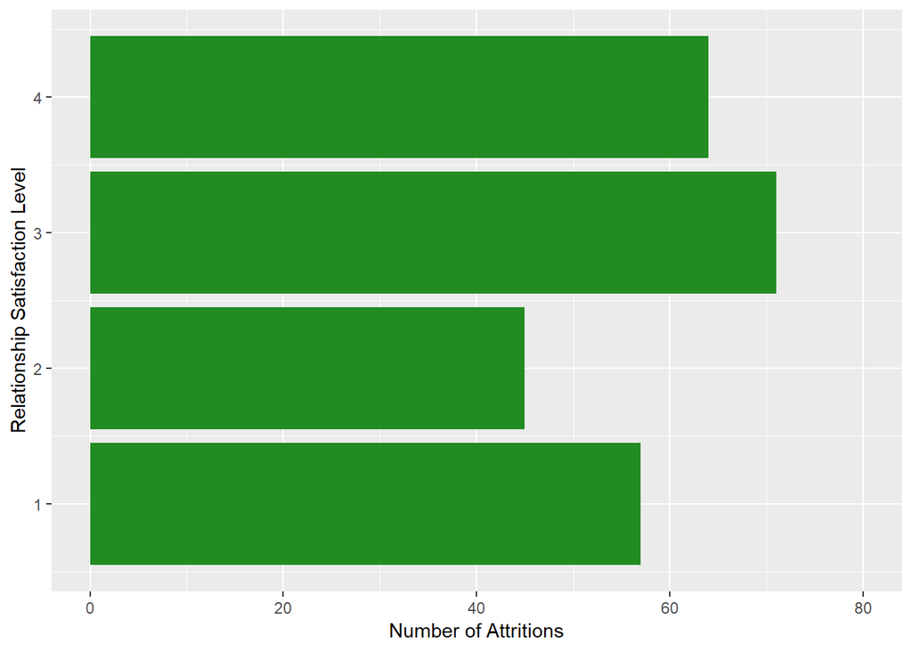

```r
RelSum <- aggregate(jobDF.eda$AttritionInd, by=list(Category=jobDF.eda$RelationshipSatisfaction), FUN=sum)
ggplot(RelSum, aes(y=x, x=Category)) + geom_bar(position="dodge", stat="identity", fill=c("forestgreen")) + scale_x_continuous(name="Relationship Satisfaction Level") + scale_y_continuous(name="Number of Attritions", limits=c(0, 80)) + coord_flip()
```

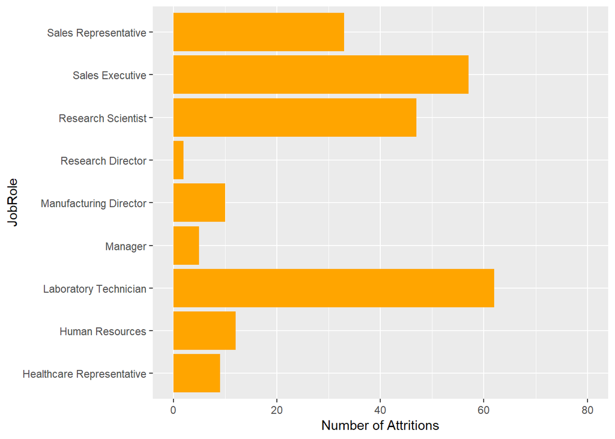

```r
RoleSum <- aggregate(jobDF.eda$AttritionInd, by=list(JobRole=jobDF.eda$JobRole), FUN=sum)
ggplot(RoleSum, aes(y=x, x=JobRole)) + geom_bar(position="dodge", stat="identity", fill=c("orange")) + scale_y_continuous(name="Number of Attritions", limits=c(0, 80)) + coord_flip()
```

EDA: Exploring the data distribution

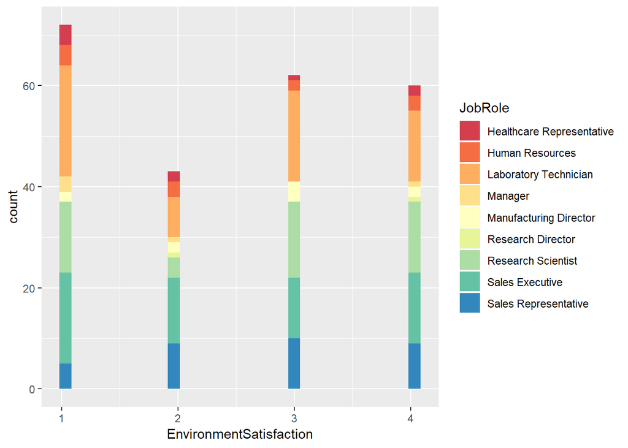

```r
CSDf<-jobDF[which(jobDF$Attrition=="Yes"),]
ggplot(CSDf,aes(EnvironmentSatisfaction))+scale_fill_brewer(palette="Spectral")+geom_histogram(aes(fill=JobRole))
```

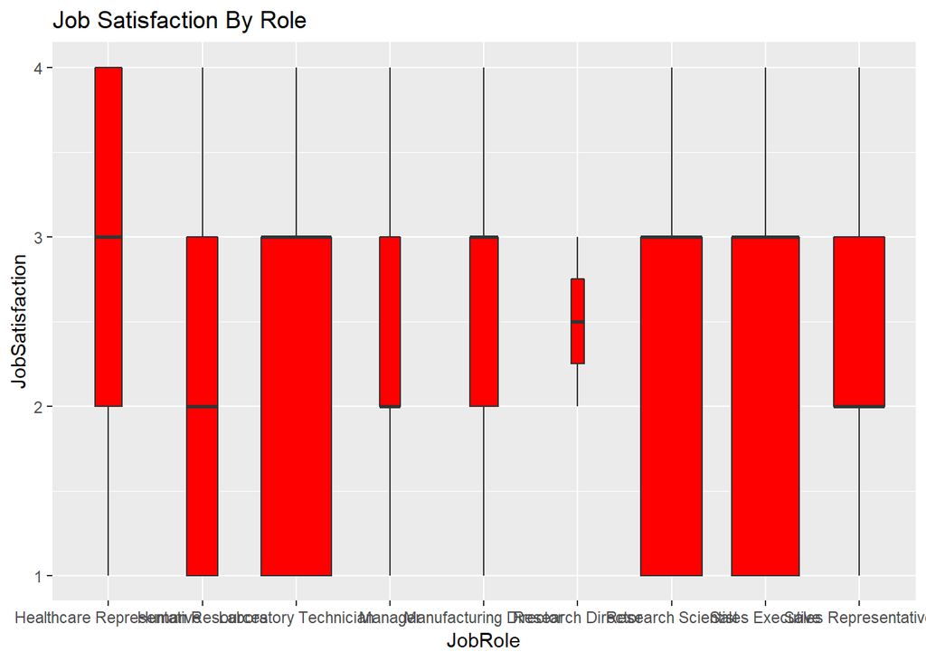

```r
ggplot(CSDf,aes(JobRole,JobSatisfaction))+geom_boxplot(varwidth = T,fill="red")+ labs(title = "Job Satisfaction By Role")
```

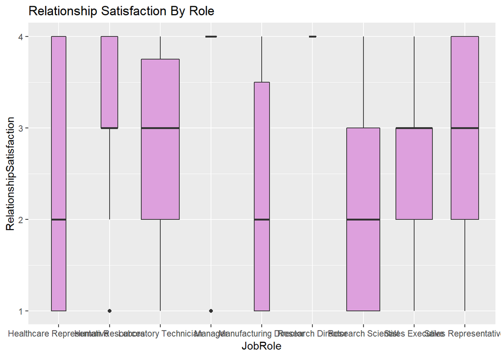

```r
ggplot(CSDf,aes(JobRole,RelationshipSatisfaction))+geom_boxplot(varwidth = T,fill="plum") +labs(title = "Relationship Satisfaction By Role")
```

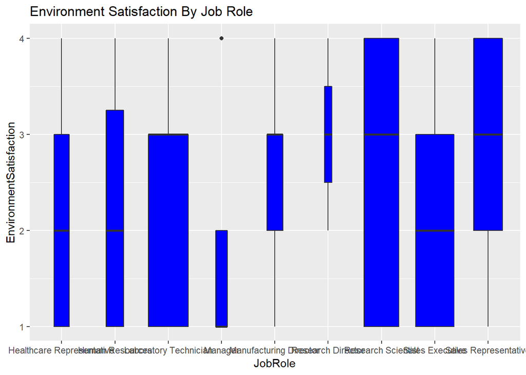

```r
ggplot(CSDf,aes(JobRole,EnvironmentSatisfaction))+geom_boxplot(varwidth = T,fill="blue")+ labs(title = "Environment Satisfaction By Job Role")
```

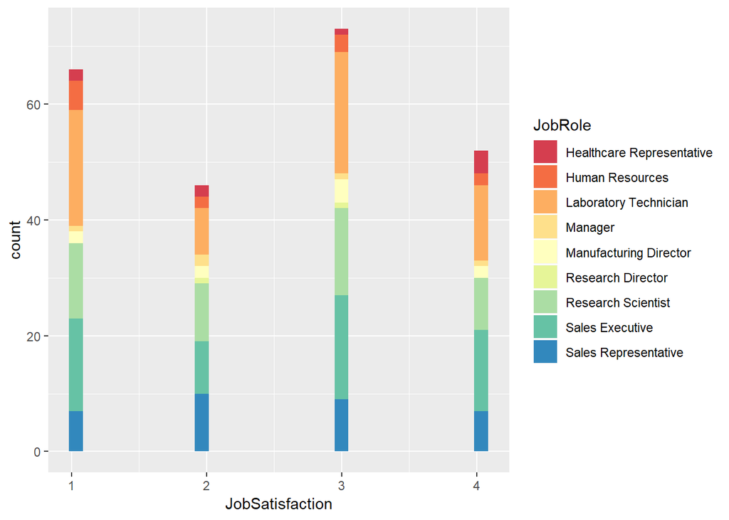

```r
 ggplot(CSDf,aes(JobSatisfaction))+scale_fill_brewer(palette = "Spectral")+geom_histogram(aes(fill=JobRole))
```

## Not sure where to begin…so let’s test them all!

Since we are looking for the top 3 variables out of several possibilities, we will use a machine learning technique known as a random forest. A random forest is a panel of decision trees designed to test several permutations of variable interactions to see which variables seem to have the most influence on a particular outcome. This makes it a powerful technique in exploration. The first step is to build a training set & test set. The training set is 70% of the data, while the test set is 30%.

```r
set.seed(26)
train <- sample(nrow(jobDF),0.7*nrow(jobDF), replace = FALSE)
jobDF.train <- jobDF[train,]
jobDF.test <- jobDF[-train,]
jobs.rf <- randomForest(Attrition ~ ., data=jobDF.train, importance=TRUE)
print(jobs.rf)
```

```
##
## Call:
##  randomForest(formula = Attrition ~ ., data = jobDF.train, importance = TRUE)
##                Type of random forest: classification
##                      Number of trees: 500
## No. of variables tried at each split: 5
##
##         OOB estimate of  error rate: 13.41%
## Confusion matrix:
##      No Yes class.error
## No  862   4 0.004618938
## Yes 134  29 0.822085890
```

## Identify the optimal mtry

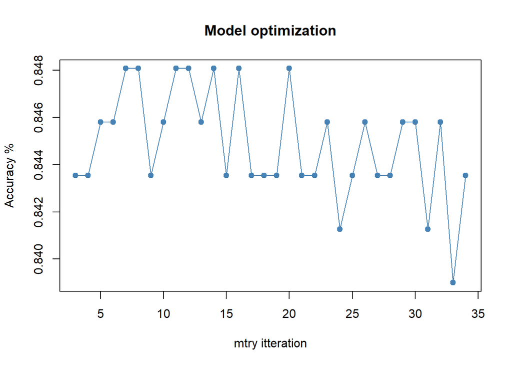

```r
a=c()
i=5
for (i in 3:34) {
  jobs.rf2<-randomForest(Attrition ~.,data = jobDF.train, ntree=500, mtry=i, importance=TRUE)
  pred_test_jobs<-predict(jobs.rf2,jobDF.test,type ="class")
  a[i-2]=mean(pred_test_jobs==jobDF.test$Attrition)
}
plot(3:34,a,pch=19,col="steel blue",type = "o",xlab = "mtry itteration", ylab = "Accuracy %",main = "Model optimization")
```

```r
jobs.rf3 <- randomForest(Attrition ~ ., data=jobDF.train, ntree=500, importance=TRUE, mtry=24)
print(jobs.rf3)
```

```
##
## Call:
##  randomForest(formula = Attrition ~ ., data = jobDF.train, ntree = 500,      importance = TRUE, mtry = 24)
##                Type of random forest: classification
##                      Number of trees: 500
## No. of variables tried at each split: 24
##
##         OOB estimate of  error rate: 12.83%
## Confusion matrix:
##      No Yes class.error
## No  853  13  0.01501155
## Yes 119  44  0.73006135
```

## Let’s predict!

```r
jobRFPred <-predict(jobs.rf3,jobDF.test,type = "class")
mean(pred_test_jobs==jobDF.test$Attrition)
```

```
## [1] 0.8435374
```

```r
kable(table(pred_test_jobs,jobDF.test$Attrition), format = "html", align = "c") %>% kable_styling(bootstrap_options = c("striped", "hover"))
```

|  | No | Yes |
| --- | --- | --- |
| No | 361 | 63 |
| Yes | 6 | 11 |

```r
#kable(table(pred_test_jobs,jobDF.test$Attrition), align = "c") %>% kable_styling(bootstrap_options = c("striped", "hover"))
```

## Prediction test supports the accuracy we found earlier. Let’s use this to pick our top 3 variables.

```r
importanceDF <- data.frame(round(importance(jobs.rf3),2))
sortYes <- importanceDF[order(importanceDF$Yes,decreasing = TRUE),]
kable(sortYes, format = "html", align = "c") %>% kable_styling(bootstrap_options = c("striped", "hover"))
```

|  | No | Yes | MeanDecreaseAccuracy | MeanDecreaseGini |
| --- | --- | --- | --- | --- |
| OverTime | 18.83 | 32.14 | 30.70 | 19.90 |
| MonthlyIncome | 11.97 | 15.21 | 19.07 | 26.81 |
| JobLevel | 4.10 | 7.53 | 7.85 | 3.36 |
| TotalWorkingYears | 11.36 | 7.28 | 13.80 | 12.34 |
| JobInvolvement | 5.37 | 7.08 | 7.93 | 7.84 |
| DailyRate | 5.51 | 6.92 | 8.54 | 19.36 |
| EnvironmentSatisfaction | 4.69 | 6.19 | 7.21 | 8.98 |
| JobRole | 10.84 | 4.69 | 12.02 | 14.13 |
| YearsAtCompany | 8.61 | 4.59 | 10.42 | 11.17 |
| YearsWithCurrManager | 8.70 | 4.24 | 9.51 | 7.60 |
| AgeGroup | 9.35 | 4.02 | 10.19 | 8.30 |
| BusinessTravel | 4.77 | 3.56 | 5.52 | 4.14 |
| YearsInCurrentRole | 7.34 | 3.48 | 8.66 | 5.04 |
| EducationField | 3.12 | 3.44 | 4.10 | 10.51 |
| DistanceFromHome | 1.59 | 3.29 | 2.82 | 11.65 |
| JobSatisfaction | 1.67 | 2.93 | 2.76 | 6.07 |
| YearsSinceLastPromotion | 1.88 | 2.67 | 2.80 | 6.70 |
| StockOptionLevel | 5.41 | 2.54 | 6.03 | 6.09 |
| MaritalStatus | 5.51 | 2.49 | 5.59 | 4.57 |
| Department | -0.46 | 2.46 | 0.50 | 1.06 |
| NumCompaniesWorked | 3.34 | 1.82 | 3.76 | 9.79 |
| WorkLifeBalance | -0.13 | 1.44 | 0.46 | 6.61 |
| TrainingTimesLastYear | 3.08 | 1.12 | 3.23 | 7.86 |
| HourlyRate | 0.66 | 0.95 | 1.08 | 12.62 |
| EmployeeCount | 0.00 | 0.00 | 0.00 | 0.00 |
| Over18 | 0.00 | 0.00 | 0.00 | 0.00 |
| StandardHours | 0.00 | 0.00 | 0.00 | 0.00 |
| GenderInd | -0.09 | -0.30 | -0.32 | 1.58 |
| PerformanceRating | -0.49 | -0.85 | -0.77 | 0.59 |
| EmployeeNumber | 0.25 | -1.04 | -0.26 | 10.93 |
| Education | 0.65 | -1.18 | 0.10 | 4.86 |
| PercentSalaryHike | 0.82 | -1.43 | 0.10 | 6.41 |
| RelationshipSatisfaction | 0.23 | -1.55 | -0.41 | 4.64 |
| MonthlyRate | -2.64 | -1.98 | -3.33 | 13.05 |

```r
#kable(sortYes, align = "c") %>% kable_styling(bootstrap_options = c("striped", "hover"))
```

## Let’s take a look at a more detailed breakdown

```r
#explain_forest(jobs.rf3, data=jobDF)
```

## Let’s plot importance for each variable

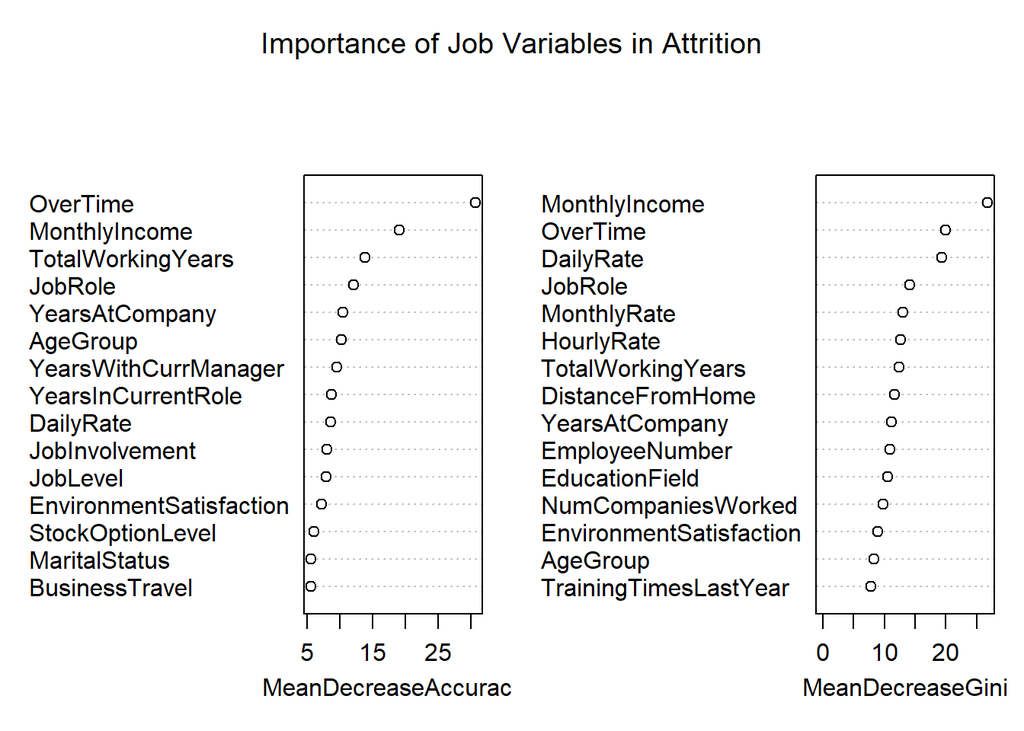

```r
varImpPlot(jobs.rf3, main="Importance of Job Variables in Attrition", n.var=15)
```

Since this is a model with a binary response (someone will attrite or they will not), we will test a logistic regression model. It’s important to recognize that this model predicts if the included variables will have an impact (either way) on the attrition outcome, not that they are entirely predictive of positive attrition.

```r
jobs.glm <- glm(Attrition ~ MonthlyIncome + EnvironmentSatisfaction + OverTime, data=jobDF, family=binomial(link='logit'))
kable(tidy(jobs.glm), format = "html", align = "c") %>% kable_styling(bootstrap_options = c("striped", "hover"))
```

| term | estimate | std.error | statistic | p.value |
| --- | --- | --- | --- | --- |
| (Intercept) | -0.5231823 | 0.2259298 | -2.315685 | 0.0205755 |
| MonthlyIncome | -0.0001402 | 0.0000227 | -6.185634 | 0.0000000 |
| EnvironmentSatisfaction | -0.3396194 | 0.0693113 | -4.899914 | 0.0000010 |
| OverTimeYes | 1.4741367 | 0.1538107 | 9.584095 | 0.0000000 |

```r
kable(pR2(jobs.glm), format = "html", align = "c") %>% kable_styling(bootstrap_options = c("striped", "hover"))
```

|  | x |
| --- | --- |
| llh | -571.7344869 |
| llhNull | -649.2913504 |
| G2 | 155.1137270 |
| McFadden | 0.1194485 |
| r2ML | 0.1001431 |
| r2CU | 0.1707119 |

```r
#kable(tidy(jobs.glm), align = "c") %>% kable_styling(bootstrap_options = c("striped", "hover"))
#kable(pR2(jobs.glm), align = "c") %>% kable_styling(bootstrap_options = c("striped", "hover"))
```

In a linear regression model, the adjusted R-Squared is the most broadly accepted statistic for “accuracy.” In logistic regression, the closest equivalent is the McFadden log likelihood. In this case, the model with the above parameters produces 11.9% McFadden score - indicating that this model contributes to roughly 11.9% of the variance in attrition outcomes.

## Other observations

Our random forest algorithm has also postulated the top factors that contribution to a person remaining in their job. Let’s go through a similar exercise:

```r
sortNo <- importanceDF[order(importanceDF$No,decreasing = TRUE),]
kable(sortNo, format = "html", align = "c") %>% kable_styling(bootstrap_options = c("striped", "hover"))
```

|  | No | Yes | MeanDecreaseAccuracy | MeanDecreaseGini |
| --- | --- | --- | --- | --- |
| OverTime | 18.83 | 32.14 | 30.70 | 19.90 |
| MonthlyIncome | 11.97 | 15.21 | 19.07 | 26.81 |
| TotalWorkingYears | 11.36 | 7.28 | 13.80 | 12.34 |
| JobRole | 10.84 | 4.69 | 12.02 | 14.13 |
| AgeGroup | 9.35 | 4.02 | 10.19 | 8.30 |
| YearsWithCurrManager | 8.70 | 4.24 | 9.51 | 7.60 |
| YearsAtCompany | 8.61 | 4.59 | 10.42 | 11.17 |
| YearsInCurrentRole | 7.34 | 3.48 | 8.66 | 5.04 |
| DailyRate | 5.51 | 6.92 | 8.54 | 19.36 |
| MaritalStatus | 5.51 | 2.49 | 5.59 | 4.57 |
| StockOptionLevel | 5.41 | 2.54 | 6.03 | 6.09 |
| JobInvolvement | 5.37 | 7.08 | 7.93 | 7.84 |
| BusinessTravel | 4.77 | 3.56 | 5.52 | 4.14 |
| EnvironmentSatisfaction | 4.69 | 6.19 | 7.21 | 8.98 |
| JobLevel | 4.10 | 7.53 | 7.85 | 3.36 |
| NumCompaniesWorked | 3.34 | 1.82 | 3.76 | 9.79 |
| EducationField | 3.12 | 3.44 | 4.10 | 10.51 |
| TrainingTimesLastYear | 3.08 | 1.12 | 3.23 | 7.86 |
| YearsSinceLastPromotion | 1.88 | 2.67 | 2.80 | 6.70 |
| JobSatisfaction | 1.67 | 2.93 | 2.76 | 6.07 |
| DistanceFromHome | 1.59 | 3.29 | 2.82 | 11.65 |
| PercentSalaryHike | 0.82 | -1.43 | 0.10 | 6.41 |
| HourlyRate | 0.66 | 0.95 | 1.08 | 12.62 |
| Education | 0.65 | -1.18 | 0.10 | 4.86 |
| EmployeeNumber | 0.25 | -1.04 | -0.26 | 10.93 |
| RelationshipSatisfaction | 0.23 | -1.55 | -0.41 | 4.64 |
| EmployeeCount | 0.00 | 0.00 | 0.00 | 0.00 |
| Over18 | 0.00 | 0.00 | 0.00 | 0.00 |
| StandardHours | 0.00 | 0.00 | 0.00 | 0.00 |
| GenderInd | -0.09 | -0.30 | -0.32 | 1.58 |
| WorkLifeBalance | -0.13 | 1.44 | 0.46 | 6.61 |
| Department | -0.46 | 2.46 | 0.50 | 1.06 |
| PerformanceRating | -0.49 | -0.85 | -0.77 | 0.59 |
| MonthlyRate | -2.64 | -1.98 | -3.33 | 13.05 |

```r
#kable(sortNo, align = "c") %>% kable_styling(bootstrap_options = c("striped", "hover"))
```

It looks like some of the same factors that lead to attrition can also contribute to someone remaining in their current role. Let’s adjust the model for a “No” response assumption:

```r
jobsNo.glm <- glm(Attrition ~ MonthlyIncome + TotalWorkingYears + OverTime, data=jobDF, family=binomial(link='logit'))
kable(tidy(jobsNo.glm), format = "html", align = "c") %>% kable_styling(bootstrap_options = c("striped", "hover"))
```

| term | estimate | std.error | statistic | p.value |
| --- | --- | --- | --- | --- |
| (Intercept) | -1.2576143 | 0.1533876 | -8.198929 | 0.0000000 |
| MonthlyIncome | -0.0000681 | 0.0000309 | -2.204935 | 0.0274586 |
| TotalWorkingYears | -0.0540751 | 0.0174504 | -3.098782 | 0.0019432 |
| OverTimeYes | 1.3964687 | 0.1508408 | 9.257896 | 0.0000000 |

```r
kable(pR2(jobsNo.glm), format = "html", align = "c") %>% kable_styling(bootstrap_options = c("striped", "hover"))
```

|  | x |
| --- | --- |
| llh | -578.7809665 |
| llhNull | -649.2913504 |
| G2 | 141.0207678 |
| McFadden | 0.1085959 |
| r2ML | 0.0914747 |
| r2CU | 0.1559349 |

```r
#kable(tidy(jobsNo.glm), align = "c") %>% kable_styling(bootstrap_options = c("striped", "hover"))
#kable(pR2(jobsNo.glm), align = "c") %>% kable_styling(bootstrap_options = c("striped", "hover"))
```

This produces a McFadden score of 10.8%.